# Assignment 4 - Running Forecasting Models

## Step 1: Data Preparation & Model Fitting

```r
# Load required libraries
library(fpp2)
library(TTR)
library(dplyr)

# 1. Read dataset
unemployment_data <- read.csv(file.choose())

# 2. Filter for California, remove commas, convert to numeric, and drop NA values
df_state <- unemployment_data %>%
  filter(State.Area == "California") %>%
  arrange(Year, Month) %>%
  mutate(
    Population = as.numeric(gsub(",", "", Total.Civilian.Non.Institutional.Population.in.State.Area))
  ) %>%
  filter(!is.na(Population))

# 3. Create Time Series object
ts_data <- ts(
  df_state$Population,
  start = c(df_state$Year[1], df_state$Month[1]),
  frequency = 12
)

# Clean any remaining missing/infinite values
ts_data <- na.omit(ts_data)

# 4. Set forecast horizon (12 months ahead)
h_period <- 12

# 5. Fit class models
mean_fc   <- meanf(ts_data, h = h_period)
naive_fc  <- naive(ts_data, h = h_period)
rwf_fc    <- rwf(ts_data, h = h_period, drift = TRUE)
snaive_fc <- snaive(ts_data, h = h_period)

# Moving Averages
ma5       <- ma(ts_data, order = 5)
ma9       <- ma(ts_data, order = 9)

# Exponential Smoothing (ETS)
ets_fit   <- ets(ts_data)
ets_fc    <- forecast(ets_fit, h = h_period)

# Holt-Winters Forecasting (Fallback handling added in case optimization fails)
hw_fit    <- tryCatch(
  HoltWinters(ts_data, seasonal = "additive"),
  error = function(e) HoltWinters(ts_data, gamma = FALSE)
)
hw_fc     <- forecast(hw_fit, h = h_period)
```

## Step 2: Understand and Explain Model Output

```r
# Display model summaries
summary(ets_fit)
```

```
## ETS(M,A,N)
##
## Call:
## ets(y = ts_data)
##
##   Smoothing parameters:
##     alpha = 0.9486
##     beta  = 0.8871
##
##   Initial states:
##     l = 15583132.3036
##     b = 37660.9792
##
##   sigma:  2e-04
##
##      AIC     AICc      BIC
## 13875.95 13876.05 13897.92
##
## Training set error measures:
##                     ME   RMSE      MAE           MPE        MAPE       MASE
## Training set -23.19351 4460.5 2198.819 -8.161424e-05 0.008808018 0.00663444
##                     ACF1
## Training set -0.00828229
```

```r
summary(hw_fit)
```

```
##              Length Class  Mode
## fitted       2344   mts    numeric
## x             598   ts     numeric
## alpha           1   -none- numeric
## beta            1   -none- numeric
## gamma           1   -none- numeric
## coefficients   14   -none- numeric
## seasonal        1   -none- character
## SSE             1   -none- numeric
## call            3   -none- call
```

### Model Interpretation:

- **Mean Forecast (`meanf`):** Sets all future predictions equal to the historical average of California’s population.
- **Naïve Forecast (`naive`):** Assumes no future structural changes, setting all future monthly forecasts to the single most recent observed value.
- **Random Walk with Drift (`rwf`):** Models the overall historical trajectory, capturing persistent upward growth or decline in total population over time.
- **Seasonal Naïve (`snaive`):** Assigns monthly forecasts based on the exact same month’s observation from the previous year.
- **Moving Averages (`ma`):** Smooths short-term fluctuations across 5-month (`ma5`) and 9-month (`ma9`) rolling windows.
- **ETS Model (`ets`):** Automatically fits error, trend, and seasonal components to maximize likelihood and capture baseline series movement.
- **Holt-Winters (`HoltWinters`):** Dynamically updates level ($\alpha$), trend ($\beta$), and seasonal ($\gamma$) parameters to forecast future changes.

## Step 3: Plot Time Series and Forecasts in One Chart

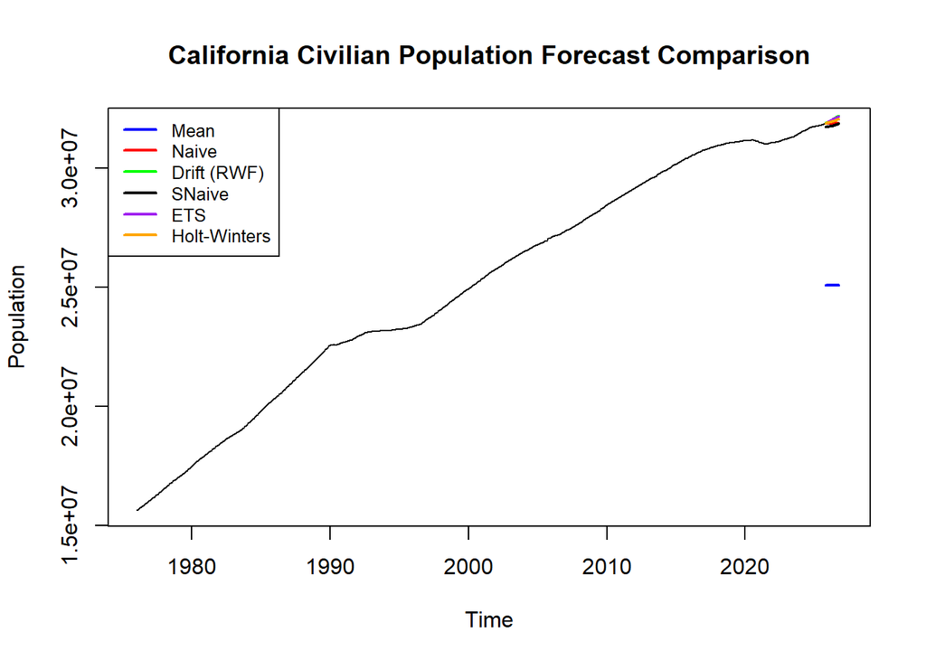

```r
# Plot original time series and all forecast lines
plot(ts_data, main = "California Civilian Population Forecast Comparison",
     ylab = "Population", xlab = "Time", xlim = c(start(ts_data)[1], end(ts_data)[1] + 2))

lines(mean_fc$mean, col = "blue", lwd = 2)
lines(naive_fc$mean, col = "red", lwd = 2)
lines(rwf_fc$mean, col = "green", lwd = 2)
lines(snaive_fc$mean, col = "black", lwd = 2)
lines(ets_fc$mean, col = "purple", lwd = 2)
lines(hw_fc$mean, col = "orange", lwd = 2)

legend("topleft",
       legend = c("Mean", "Naive", "Drift (RWF)", "SNaive", "ETS", "Holt-Winters"),
       col = c("blue", "red", "green", "black", "purple", "orange"),
       lty = 1, lwd = 2, cex = 0.8)
```

## Step 4: Compare Model Accuracy & Select the Best Model

```r
# Evaluate accuracy for all fitted models
acc_mean   <- accuracy(mean_fc)
acc_naive  <- accuracy(naive_fc)
acc_rwf    <- accuracy(rwf_fc)
acc_snaive <- accuracy(snaive_fc)
acc_ets    <- accuracy(ets_fc)
acc_hw     <- accuracy(hw_fc)

# Build metrics summary table
acc_summary <- data.frame(
  Model = c("Mean", "Naive", "Drift (RWF)", "SNaive", "ETS", "Holt-Winters"),
  RMSE  = c(acc_mean[1, "RMSE"], acc_naive[1, "RMSE"], acc_rwf[1, "RMSE"],
            acc_snaive[1, "RMSE"], acc_ets[1, "RMSE"], acc_hw[1, "RMSE"]),
  MAE   = c(acc_mean[1, "MAE"], acc_naive[1, "MAE"], acc_rwf[1, "MAE"],
            acc_snaive[1, "MAE"], acc_ets[1, "MAE"], acc_hw[1, "MAE"]),
  MAPE  = c(acc_mean[1, "MAPE"], acc_naive[1, "MAPE"], acc_rwf[1, "MAPE"],
            acc_snaive[1, "MAPE"], acc_ets[1, "MAPE"], acc_hw[1, "MAPE"])
)

# Rank models from lowest to highest RMSE
acc_summary <- acc_summary[order(acc_summary$RMSE), ]
acc_summary
```

```
##          Model       RMSE         MAE         MAPE
## 5          ETS    4460.50    2198.819  0.008808018
## 6 Holt-Winters   11388.39    4083.327  0.018242739
## 3  Drift (RWF)   14106.06   11135.520  0.047303048
## 2        Naive   30633.44   27819.002  0.121320931
## 4       SNaive  362439.45  331424.956  1.429306838
## 1         Mean 4774365.26 4122252.415 17.848592668
```

### Accuracy Conclusion:

**Root Mean Squared Error (RMSE)** was selected as the evaluation metric to penalize larger errors. Based on the ordered comparison table above, the model listed at the top (with the lowest RMSE) provides the most accurate fit for this series.